# GPGPU in R

Biostat 203B

Jianxiao Yang

Mar 8, 2022

## General-purpose computing on GPU (GPGPU)

GPGPU is the use of a graphics processing unit (GPU), which typically handles computation only for computer graphics, to perform computation in applications traditionally handled by the CPU.

GPGPU is fundamentally a software concept, not a hardware concept; it is a type of algorithm, not a piece of equipment.

GPUs are often conveniently available on standard laptops and desktop computers and can be externally connected to a personal computer.

### GPU architecture and memory hierarchy

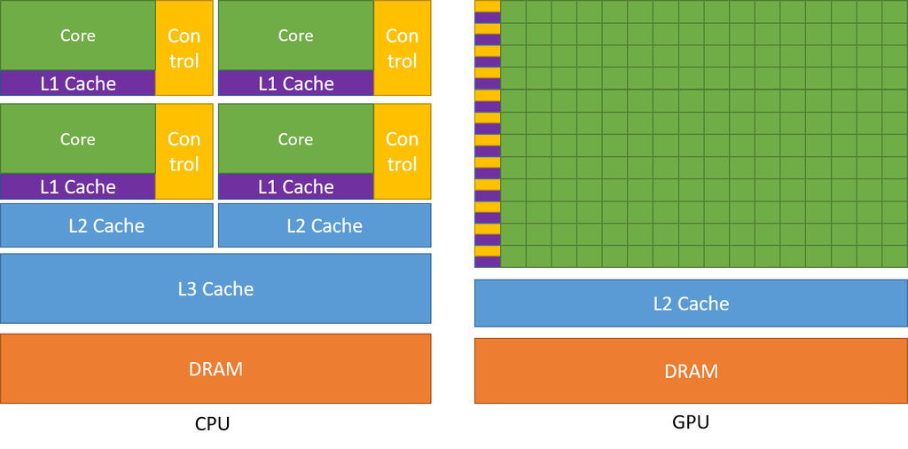

GPU consists of multiprocessor element that run under the shared-memory threads model. GPUs can run hundreds or thousands of threads in parallel.

- Local memory
  - Each thread has private local memory.
- Shared memory
  - Each thread block has shared memory visible to all threads of the block.
- Global memory
  - All threads have access to the same global memory.

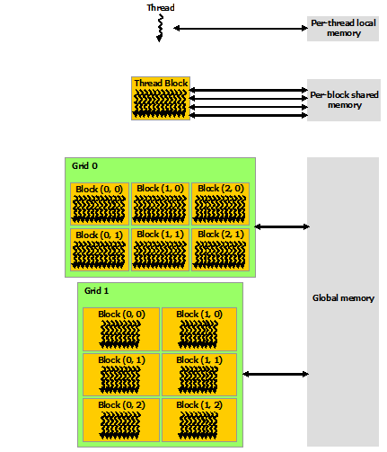

### GPGPU platform

- CUDA
  - CUDA is a software development kit (SDK) and application programming interface (API) that allows using the programming language C/C++ to code algorithms for execution on NVIDIA GPUs.
  - There are extensive CUDA libraries for scientific computing: CUB, Thrust, CuBLAS, CuRAND, CuSparse, ...
- OpenCL
  - OpenCL is an open-source GPGPU framework that can execute programs on GPUs from many manufacturers including Nvidia and AMD, but lacks some libraries essential for statistical computing.

### Heterogeneous programming

- Basic concepts
  - Host: The CPU and its memory (host memory)
  - Device: The GPU and its memory (device memory)
  - Kernel: Parallel code that launched and executed on a device by many threads, as opposed to only one like regular **function**
- Workflow
  - Write code for the device (kernel)
  - Write code for the host to launch the kernel
  - Pass runtime and algorithmic parameters and launch the kernel
  - Manage memory transactions between host and device

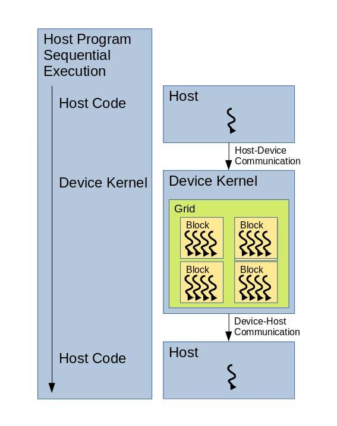

## GPGPU in R

- Use existing R GPU packages from CRAN (check https://cran.r-project.org/web/views/HighPerformanceComputing.html)
  - The [OpenCL package](https://cran.r-project.org/web/packages/OpenCL/index.html)
- Access the GPU through CUDA/OpenCL-accelerated programming launguages such as C/C++
  - Be able to flexibly benefit from many GPU-accelerated libraries (from NVIDIA or other open-source libraries).
  - Use the GPU through heterogeneous programming with CUDA/OpenCL directly.
  - Need to build an interface through C/C++ to bridge R and CUDA/OpenCL.

### Examples

```r
n = 10^6
x1 = rnorm(n)
x2 = rnorm(n)
```

#### Add two vectors

```r
add_r <- function(x1, x2) {
  out <- rep(length(x1), 0.0)
  for (i in 1:length(x1)) {
    out[i] <- x1[i] + x2[i]
  }
  return(out)
}
add_r
```

```
## function(x1, x2) {
##   out <- rep(length(x1), 0.0)
##   for (i in 1:length(x1)) {
##     out[i] <- x1[i] + x2[i]
##   }
##   return(out)
## }
```

```r
library(compiler)
add_rc <- cmpfun(add_r)
```

```r
library(Rcpp)
cppFunction('NumericVector add_c(NumericVector x1, NumericVector x2) {
  int n = x1.size();
  NumericVector out (n);
  for(int i = 0; i < n; i++) {
    out[i] = x1[i] + x2[i];
  }
  return out;
}')
add_c
```

```
## function (x1, x2)
## .Call(<pointer: 0x10d0a13e0>, x1, x2)
```

```r
library(OpenCL)
platform <- oclPlatforms()[[1]] # retrieve available OpenCL platforms
device <- oclDevices(platform)[[2]] # get OpenCL devices for the given platform
ctx <- oclContext(device) # create an OpenCL context for a given device
platform
```

```
## OpenCL platform 'Apple'
```

```r
device
```

```
## OpenCL device 'Intel(R) Iris(TM) Plus Graphics 655'
```

```r
ctx
```

```
## OpenCL context <pointer: 0x7fc9b3c61980>
##   Device: OpenCL device 'Intel(R) Iris(TM) Plus Graphics 655'
##   Queue: OpenCL command queue <pointer: 0x7fc9b3ca1690>
##   Default precision: single
```

```r
# define kernel
code <- c("
   __kernel void kernel_add(
     __global float* output,
     const int n,
     __global const float* input1,
     __global const float* input2
   )
   {
      // get global thread ID
      int i = get_global_id(0);

      // make sure we do not go out of bounds
      if (i<n) output[i] = input1[i] + input2[i];
   };
")

# create and compile OpenCL kernel code
kernel_add <- oclSimpleKernel(ctx, "kernel_add", code, "single")

# create OpenCL buffer on GPU
d_x1<-clBuffer(ctx, length(x1), "single")
d_x2<-clBuffer(ctx, length(x2), "single")

# copy data from host (CPU) to device (GPU)
add_gpu_copy <- function(d_x, h_x) {
  d_x[] <- h_x
}
add_gpu_copy(d_x1, x1)
add_gpu_copy(d_x2, x2)

# run add kernel using OpenCL
add_gpu <- function(d_x1, d_x2) {
  result <- oclRun(kernel_add, length(d_x1), d_x1, d_x2)
  return(result)
}
```

```r
library(microbenchmark)
microbenchmark(add_r(x1, x2), add_rc(x1, x2), add_c(x1, x2), x1+x2,
               add_gpu(d_x1, d_x2), add_gpu_copy(d_x1, x1))
```

```
## Unit: microseconds
##                    expr        min          lq        mean     median         uq        max neval
##           add_r(x1, x2) 308052.861 326307.1795 341374.9604 338174.843 353688.306 405145.508   100
##          add_rc(x1, x2) 313752.376 327797.1000 344318.2126 340572.758 356251.533 404405.891   100
##           add_c(x1, x2)   1637.994   4282.6765   6154.1836   4527.628   5484.640  48969.388   100
##                 x1 + x2   1200.933   3794.7740   5273.5301   4084.570   4810.689  52635.951   100
##     add_gpu(d_x1, d_x2)     16.730     80.3135    123.5025     91.602    104.036   2998.559   100
##  add_gpu_copy(d_x1, x1)   2469.355   2870.3145   3646.5643   3192.154   4069.506   7848.140   100
```

#### Tree-based parallel algorithms

##### Reduction

Reductions convert an array of elements into a single result:

$$[a_0, a_1, ..., a_{n-1}] \rightarrow\sum_{i=0}^{n-1} a_i.$$

Reductions are useful for implementing log-likelihood calculations, since independent samples contribute additively to the model log-likelihood:
$$l(\beta) = \sum_i l_i(\beta).$$

##### Scan

Scans take an array and return an array:

$$[a_0, a_1, ..., a_{n-1}] \rightarrow [a_0, a_0 + a_1, ..., \sum_{i=0}^{n-1} a_i].$$

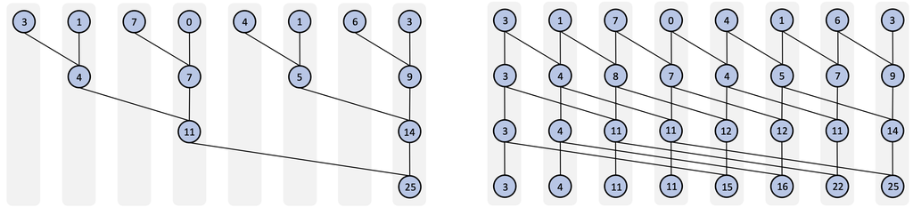

##### Use CUDA/Opencl libraries

- CUB library for efficient scan and reduction: https://nvlabs.github.io/cub/index.html
  - Single-pass Parallel Prefix Scan with Decoupled Look-back https://research.nvidia.com/sites/default/files/pubs/2016-03_Single-pass-Parallel-Prefix/nvr-2016-002.pdf
- Boost.Compute (C++ wrapper over the OpenCL API): https://github.com/boostorg/compute

```bash
cat OpenclReduce.cpp
```

```
## #include <Rcpp.h>
## #include <boost/compute.hpp>
##
## using namespace Rcpp;
##
## namespace compute = boost::compute;
##
## // [[Rcpp::export]]
## float OpenclReduce(std::vector<float>& h_x) {
##
##     // get the default compute device
##     compute::device device = compute::system::default_device();
##
##     // create a compute context and command queue
##     compute::context context(device);
##     compute::command_queue queue(context, device);
##
##     // allocate memory on the device
##     compute::vector<float> d_x(h_x.size(), context);
##
##     // copy data from the host to the device
##     compute::copy(h_x.begin(), h_x.end(), d_x.begin(), queue);
##
##     // calculate the sum and save the result back to the host
##     float total;
##     compute::reduce(d_x.begin(), d_x.end(), &total, queue);
##
##     return total;
## }
```

## Tips of using GPGPU in statistical computing

- Parallelization using GPUs generally perform better on very large sample size. When work on problems with small sample size, the communication latency costs often overpower the gains from the parallelized work.
- When optimize an existing program, start with off-loading the most computationally intensive routines to the GPU before rewriting the whole codebase.
- Apply **GPU-accelerated libraries** to gain instant speed-up. We often don't need to write complicated algorithms by ourselves.
  - CUDA GPU-Accelerated libraries: https://developer.nvidia.com/gpu-accelerated-libraries
  - A curated list of awesome OpenCL resources: https://github.com/jslee02/awesome-opencl

## Learning resources

- Introduction to Parallel Computing Tutorial: https://hpc.llnl.gov/documentation/tutorials/introduction-parallel-computing-tutorial
- Accelerate R Applications with CUDA: https://developer.nvidia.com/blog/accelerate-r-applications-cuda/
- CUDA C++ Programming Guide: https://docs.nvidia.com/cuda/cuda-c-programming-guide/index.html